# Olympics

2022-12-08

Class: SI 544 Name: Shuo Xie

Research statement: I am a graduate student in sports management and I have a great interest in sports data analysis. Therefore, I would like to use this Final Project to study the big data related to the Olympic Games. Also, as an international student from China, I am looking forward to gaining insight into the facts behind some of the data about the Chinese team in this data.

```r
library(tidyverse)
```

```r
library(infer)
library(moderndive)
library(ggplot2)
```

```r
#First, I'm going to import all the data ever counted for the Olympics, this data counted all the data from 1896-2016
oly <- read.csv("~/Downloads/athlete_events.csv")

#The following code shows the overall male vs. female comparison for the Summer and Winter Olympics ever
gender_num <- oly %>%
  group_by(Season, Sex) %>%
  count(ID) %>%
  summarise(count = n())
```

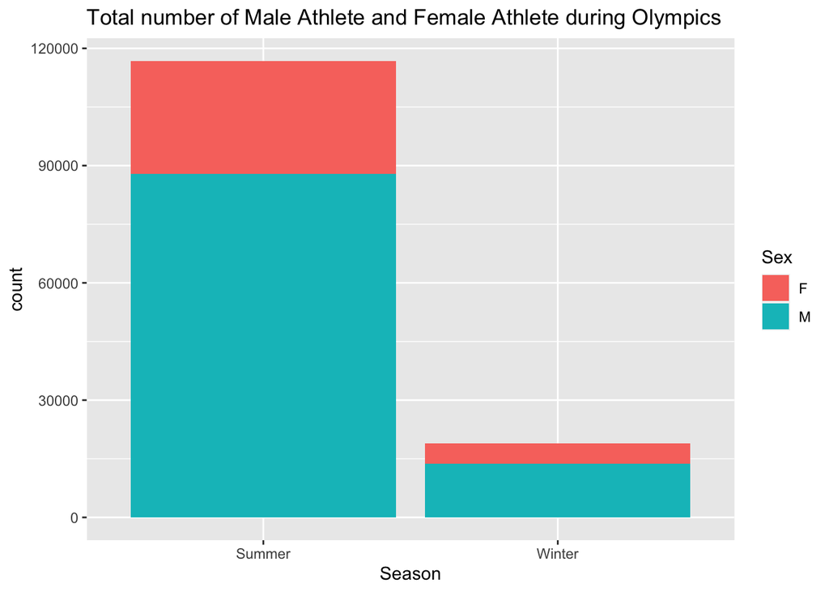

```r
#visulazation
gender_num %>%
  ggplot(aes(x= Season, y= count, fill = Sex)) +
  geom_col()+
  labs(title="Total number of Male Athlete and Female Athlete during Olympics")
```

The data below shows the change of athletes participating in the Olympic Games, and we find that the number of participants is almost gradually increasing, except for some years. For example, the 1932 Los Angeles Olympics, due to the cost, the number of participants was significantly reduced. It is worth mentioning that it was also this Olympics that China sent a delegation for the first time, that is, Liu Changchun, the first Chinese Olympian, to participate in the track and field program. 1956 Melbourne Olympics, the only Olympics in history held at a different time and place, and it was in the context of the U.S.-Soviet Cold War, and many countries abstained, the small number of people can be imagined. The Chinese delegation refused to participate in the Games because the IOC recognized the People’s Republic of China on the one hand and agreed to Taiwan’s participation in the Games under the name “Republic of China” on the other, and China seriously boycotted the Games in order to oppose the attempt to split China. In protest against the Soviet invasion of Afghanistan, the United States and other countries initiated a boycott of the Moscow Olympics, which resulted in the participation of only 80 countries, the smallest number of countries participating in the Olympics since 1956.

```r
num_year <- oly %>%
  group_by(Year,Season) %>%
  count(Name) %>%
  summarise(participants = n())
```

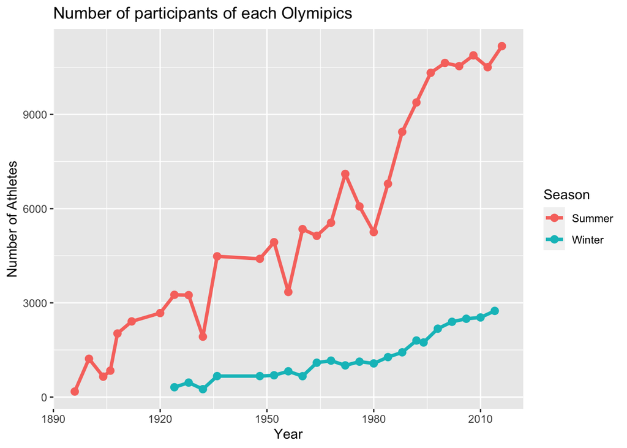

```r
num_year%>%
  ggplot(aes(x = Year, y = participants,group=Season))+
  geom_line(aes(color=Season),size =1.3)+
  geom_point(aes(color=Season),size =2.5)+
  labs(x = "Year", y = "Number of Athletes", title = "Number of participants of each Olymipics")
```

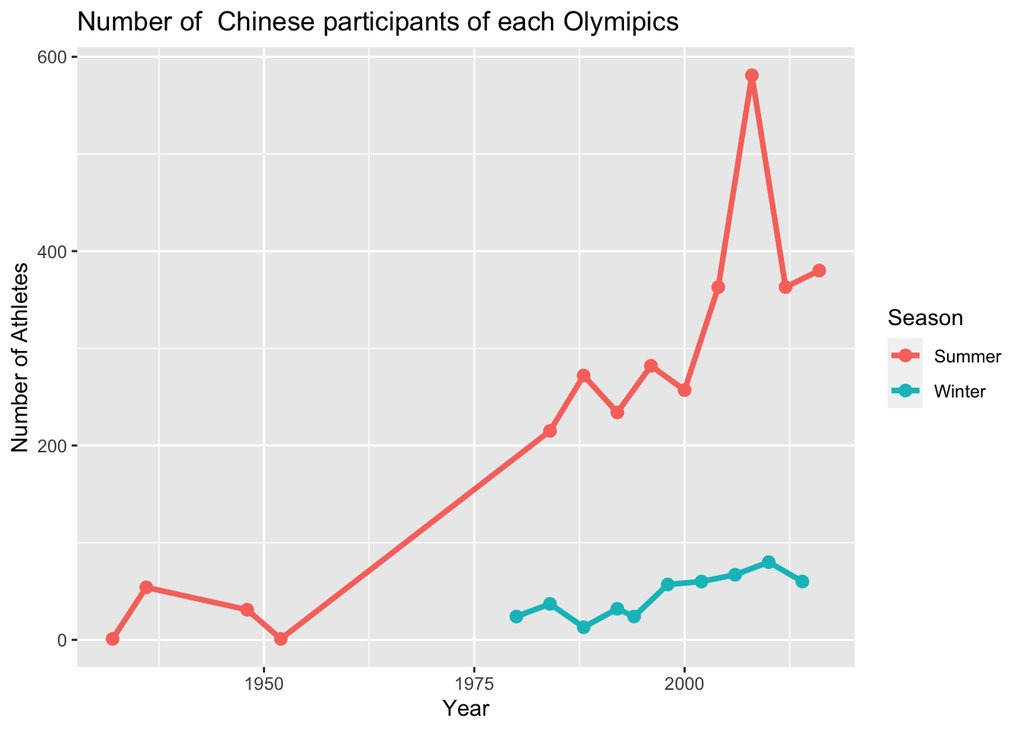

```r
#As an international student born in China, I naturally wanted to explore the changes in the number of Chinese participants in the Olympics in big data, so I created the following graph.
chinese_year <- oly %>%
  group_by(Year, Team,Season) %>%
  filter(Team=="China")%>%
  count(ID) %>%
  summarise(participants = n())
chinese_year%>%
  ggplot(aes(x = Year, y = participants,group=Season))+
  geom_line(aes(color=Season),size =1.3)+
  geom_point(aes(color=Season),size =2.5)+
  labs(x = "Year", y = "Number of Athletes", title = "Number of  Chinese participants of each Olymipics")
```

I was surprised to find that the number of Chinese participants in the Olympics peaked in 2008. Come to think of it, 2008 was also the first time that China hosted the Summer Olympics, and perhaps this is what led to so many Chinese athletes participating in the 2008 Beijing Olympics. Overall, the change in China’s participation in the Olympics is almost in line with the world But at the same time, I wanted to know how the age distribution of Chinese athletes participating in the Olympics looked like, so I created the following chart.

```r
rel_age <- oly %>%group_by(Age) %>%filter(Team=="China")%>%summarize(numofage = n())
rel_age
```

```
## # A tibble: 33 × 2
##      Age numofage
##    <int>    <int>
##  1    11        1
##  2    13        4
##  3    14       34
##  4    15       83
##  5    16      118
##  6    17      204
##  7    18      228
##  8    19      290
##  9    20      414
## 10    21      478
## # … with 23 more rows
```

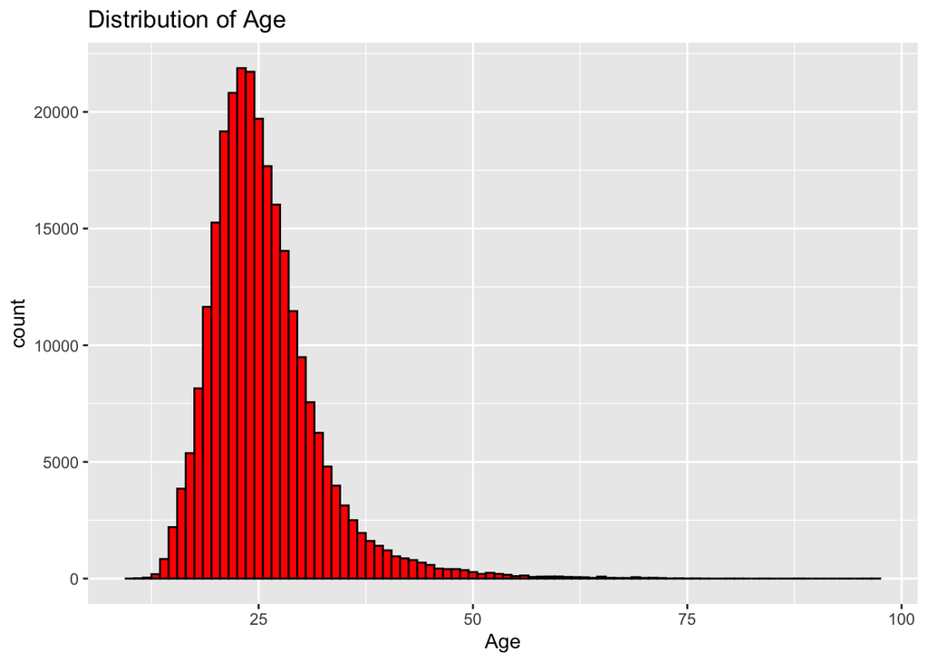

```r
ggplot(oly,aes(x = Age)) +
  geom_histogram(binwidth = 1,color = "black", fill = "red") +
  labs(x = "Age", title = "Distribution of Age")
```

I found that the largest number of people compete in the Olympics around the age of 25. Then, this also provoked me to find out the age distribution of Chinese athletes who can get gold medals in the Olympics, and the results are as follows.

```r
rel_medal <- oly %>%group_by(Age, Medal,Team) %>%filter(Team=="China",Medal=="Gold")%>%summarize(numofage = n())
```

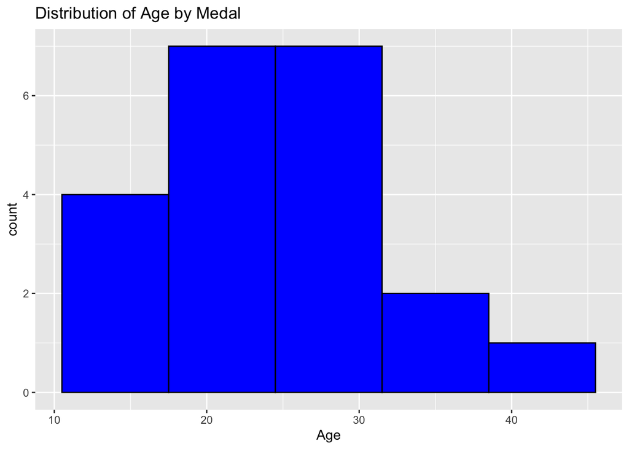

```r
ggplot(rel_medal,aes(x=Age)) +
  geom_histogram(binwidth = 7,color = "black", fill = "blue")+
  labs(x = "Age", title = "Distribution of Age by Medal")
```

I found that there is almost no difference between the age of the athletes who can win gold medals and the average age of the participants in China, all of them are around 25 years old. Therefore, it is reasonable to judge that 25 years old is a golden age for Chinese athletes. But is the average age of Chinese athletes at every Olympics 25? In order to know the answer, I used the following code to verify my guess.

```r
rel_medal_age <- oly %>%group_by(Age, Medal,Team,Year) %>%filter(Team=="China")%>%summarize(numofage = n())
age_means <- rel_medal_age%>%group_by(Year)%>%summarize(mean_age=mean(Age))
age_means
```

```
## # A tibble: 20 × 2
##     Year mean_age
##    <int>    <dbl>
##  1  1932     22
##  2  1936     23.5
##  3  1948     NA
##  4  1952     23
##  5  1980     21.7
##  6  1984     21.9
##  7  1988     22.5
##  8  1992     22.5
##  9  1994     20.9
## 10  1996     23.4
## 11  1998     21.4
## 12  2000     23.7
## 13  2002     23.6
## 14  2004     24.5
## 15  2006     23.6
## 16  2008     25.5
## 17  2010     24.3
## 18  2012     24.8
## 19  2014     22.5
## 20  2016     24.8
```

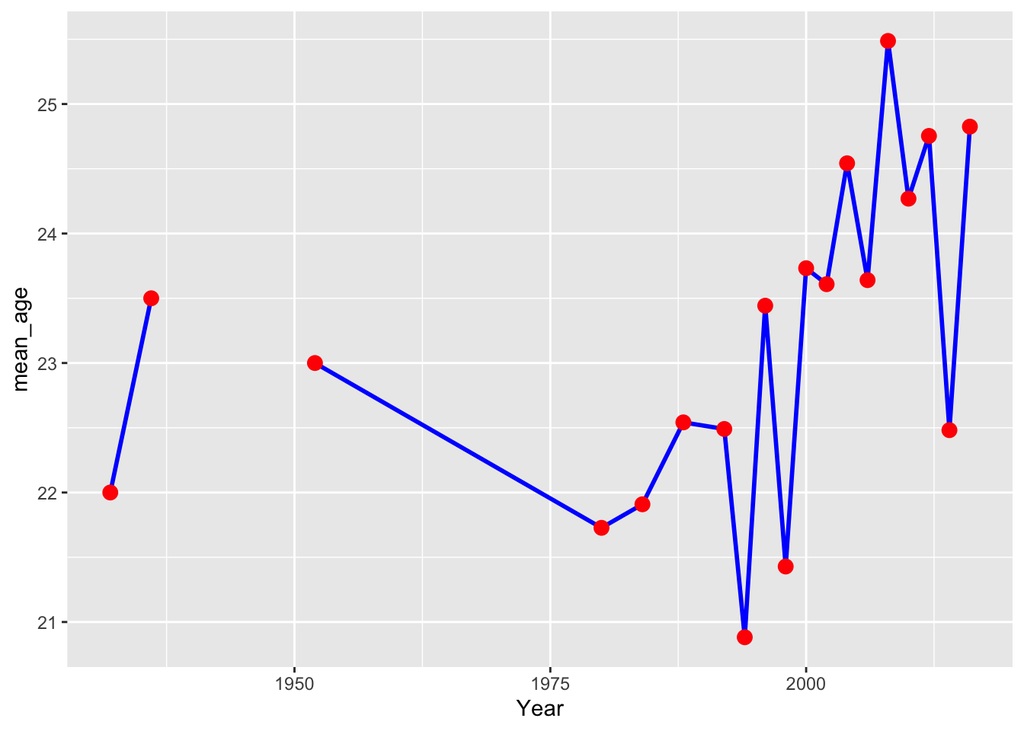

```r
ggplot(age_means,aes(x=Year,y=mean_age))+
  geom_line(size=1,color="blue")+
  geom_point(color="red",size =3)
```

As a result, I found that in almost every Olympic Games since the 21st century, the age of Chinese participants is almost 25 years old or younger. So, which of the previous Olympic Games did the Chinese team achieve the most outstanding results?

```r
rel_medal <- oly %>%group_by(Age, Medal,Team,Year,Sex) %>%filter(Team=="China",Medal=="Gold")%>%summarize(numofage = n())
```

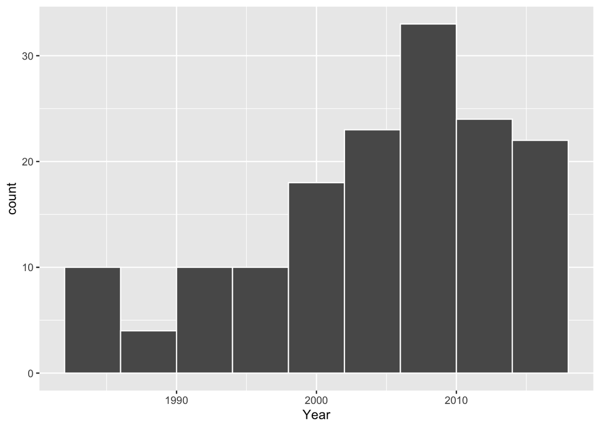

```r
ggplot(rel_medal,aes(x=Year))+
  geom_histogram(binwidth = 4,color="white")
```

Sure enough, it’s 2008! Also, I wanted to know which gender of athletes would get more gold medals, especially in 2008. So I developed the following scenario.

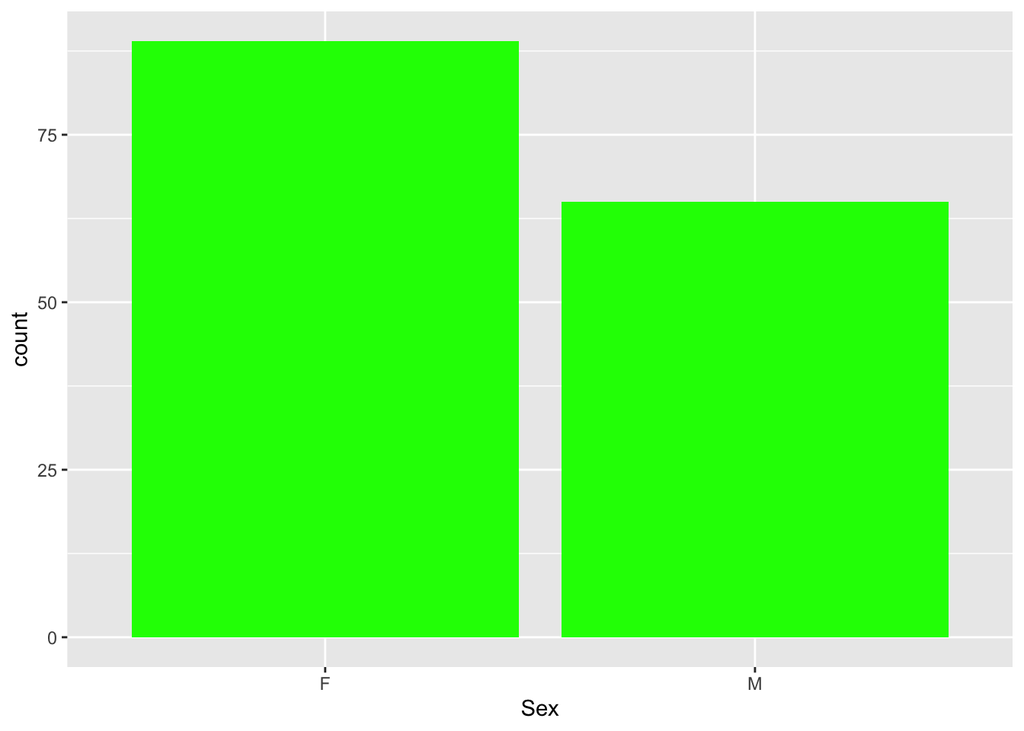

```r
#Athletes of China got gold medals in total by gender
ggplot(rel_medal,aes(x=Sex))+
  geom_bar(fill="green")
```

```r
# Atletes of China got gold medals in 2008 by gender
rel <- oly%>%group_by(Age, Medal,Team,Year,Sex) %>%filter(Team=="China",Medal=="Gold",Year=="2008")%>%summarize(numofage = n())
```

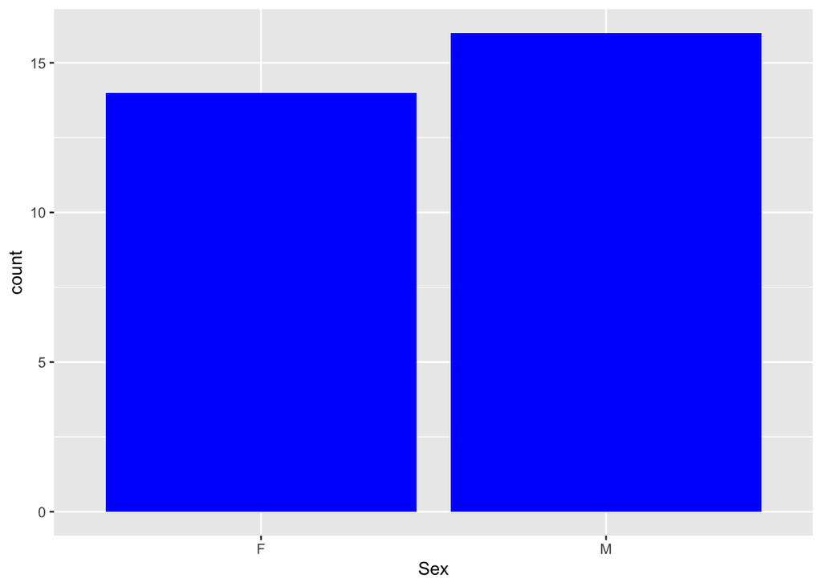

```r
ggplot(rel,aes(x=Sex))+
  geom_bar(fill="blue")
```

I made a linear model of the height and weight of the Chinese team.

```r
china_team <- oly %>%group_by(Weight,Height,Sex) %>%filter(Team=="China")%>%summarize(numofage = n())
china_team
```

```
## # A tibble: 1,272 × 4
## # Groups:   Weight, Height [983]
##    Weight Height Sex   numofage
##     <dbl>  <int> <chr>    <int>
##  1     28    137 F            2
##  2     30    136 F            6
##  3     32    139 F            5
##  4     32    140 F            5
##  5     33    140 F            6
##  6     33    142 F            5
##  7     33    144 F            6
##  8     34    143 F            5
##  9     34    144 F           10
## 10     35    142 F            5
## # … with 1,262 more rows
```

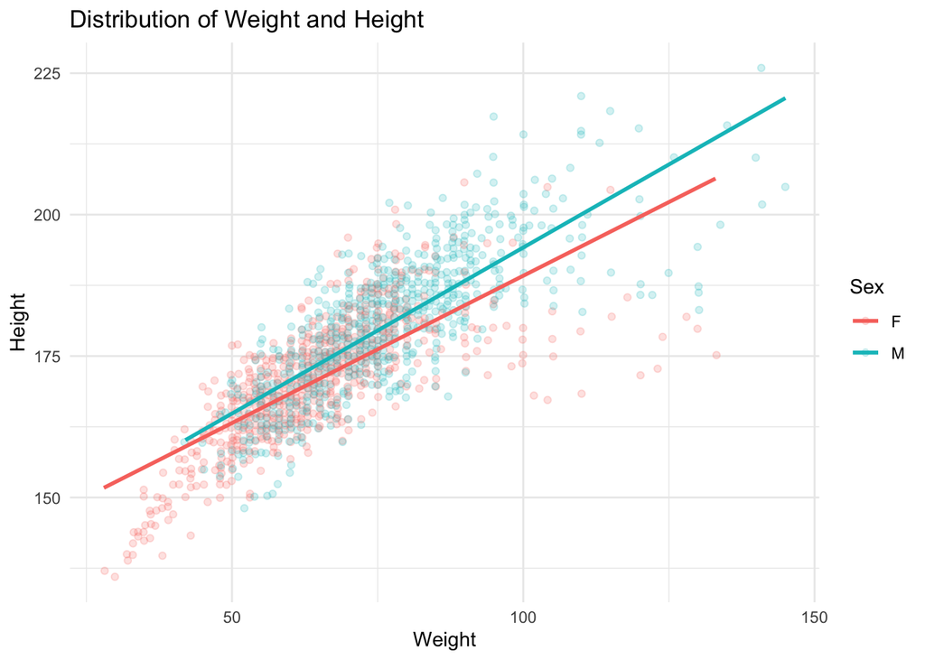

```r
china_team %>%
  ggplot(aes(x = Weight, y = Height, color = Sex)) +
  geom_point(alpha = 0.2, position = "jitter") +
  stat_smooth(method = lm, se = FALSE) +
  theme_minimal() +
  ggtitle("Distribution of Weight and Height")
```

So, while overall, China’s female athletes won more gold medals than their male counterparts, in 2008, the male athletes won more gold medals than the female athletes. After all of the above analysis, I believe that the reason for China’s top performance in 2008 may not be simply because we were the host, but also because of the following. - The largest number of Chinese athletes competed in the 2008 Olympics - The average age of Chinese athletes in the 2008 Olympics reached the “prime age”, which was around 25 years old - More male athletes won more gold medals than female athletes As a prediction, I think the Chinese delegation should try to encourage more athletes around the age of 25 to compete in future Olympics. Also, more female athletes should be encouraged to participate in the Olympics. Because overall, Chinese female athletes perform better than male athletes in the Olympics, as the old Chinese saying goes, “Who Says Women Aren’t As Good As Men?”. I think this result can be promoted, and encourage young Chinese women to participate in sports.